# Assignment02

Roland Widmer

2023-03-11

## 1

In this exercise, we consider 95%-confidence intervals for the true mean of a uniform distribution. a. Generate a sample of 30 observations from the standard uniform distribution and calculate a Student confidence interval for the true mean $\mu$. Interpret it.

```r
set.seed(1)

n <- 30
alpha <- 0.05
sample <- runif(n)

mu_hat <- mean(sample)
se_hat <- sd(sample) / sqrt(n)
t <- qt(1 - alpha/2, df = n-1)

# Student-confidence interval for mu
ci_student <- c(mu_hat - t* se_hat, mu_hat + t * se_hat)
ci_student
```

```
## [1] 0.3992930 0.6198118
```

Interpretation: True mean of 0.5 is contained. Confidence bound is quite conservative.

```
b. Calculate the Bootstrap estimate of the standard error and compare it with the usual estimate of the standard error. Plot a histogram of the Bootstrap replications.
```

Usual estimate of the standard error:

```r
# sample standard deviation
sd_hat <- sd(sample)

se_hat <- sd_hat / sqrt(n)
se_hat
```

```
## [1] 0.05391051
```

Bootstrap estimate of SE

```r
B <- 2000
boot <- numeric(B)

for (i in 1:B) {
  x_boot <- sample(sample, replace = TRUE)
  boot[i] <- mean(x_boot)
}

# Bootstrapped standard error of the mean
sd(boot)
```

```
## [1] 0.0543915
```

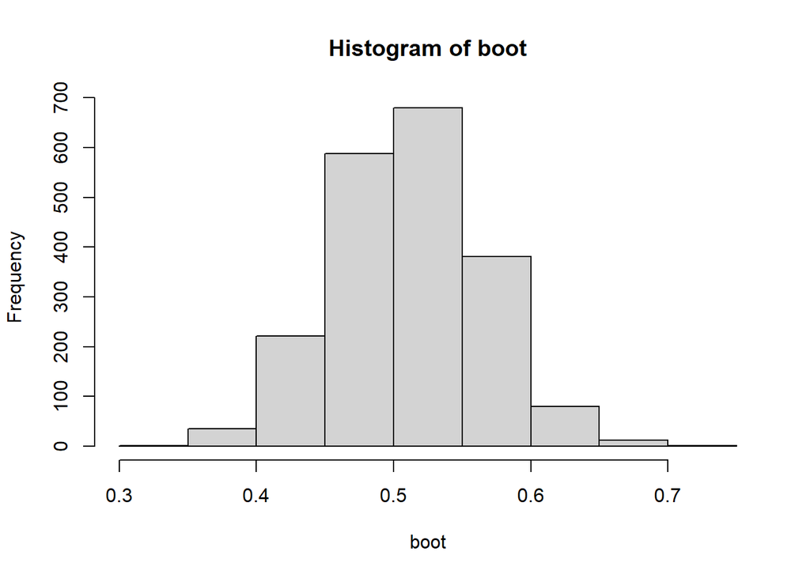

```r
hist(boot)
```

Both estimators are close to each other.

```
c. Use the `plot_stability()` function of the lecture notes to figure out after how many Bootstrap samples the Bootstrap estimate of the standard error would stabilize.
```

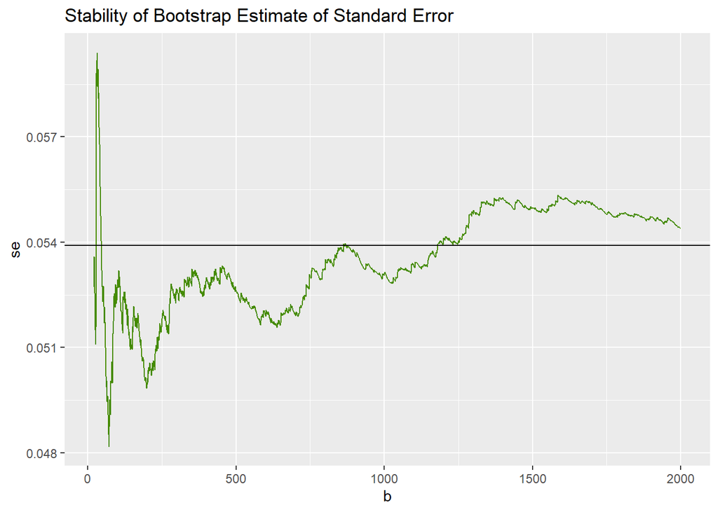

```r
plot_stability <- function(x) {  # x is the vector of Bootstrap replications
  df <- data.frame(x = x, b = 1:length(x))
  df$se <- sapply(df$b, function(i) sd(x[1:i]))  # "cumsd"

  ggplot(subset(df, b >= 20), aes(b, se)) +
    geom_line(color = "chartreuse4") +
    ggtitle("Stability of Bootstrap Estimate of Standard Error")
}

plot_stability(boot) +
  geom_hline(yintercept = sd(sample) / sqrt(n))  # Estimated standard error of the mean
```

```
d. Calculate a standard normal Bootstrap CI and a percentile Bootstrap CI for $\mu$. Compare with the interval from 1a.
```

```r
ci_boot <- mu_hat + c(-1, 1) * qnorm(1 - alpha/2) * sd(boot)

ci_boot
```

```
## [1] 0.4029470 0.6161578
```

```r
ci_student
```

```
## [1] 0.3992930 0.6198118
```

Close to each other.

## 2

Important: order of y_2 and y_1.

```r
y_1 = runif(21)
y_2 = runif(51)

estimator <- function(x, y) {
  median(y) - median(x)
}

boot <- replicate(
  9999,
  estimator(
    sample(y_1, replace = TRUE),
    sample(y_2, replace = TRUE)
  )
)

ci_boot_perc <- quantile(boot, c(alpha/2, 1-alpha/2))
ci_boot_std <- estimator(y_1, y_2) + c(-1, 1) * qnorm(1 - alpha/2) * sd(boot)

ci_boot_perc
```

```
##        2.5%       97.5%
## -0.40714466  0.04414828
```

```r
ci_boot_std
```

```
## [1] -0.40446727  0.07283112
```

## 3

For the situation in Exercise 1, use simulation to estimate real coverage probabilities of the Student CI and the two types of Bootstrap CIs. What do you observe?

```r
library(tidyverse)
n <- 30
b <- 9999
n_sim <- 1000

set.seed(1)

ci <- function(x, alpha = 0.05) {
  q <- qt(1 - alpha / 2, df=n-1)
  se <- sd(x) / sqrt(length(x))
  mu_hat <- mean(x)

  boot <- replicate(B,
    mean(sample(x, replace = TRUE))
  )

  out <- c(mu_hat,
    mu_hat + c(-1, 1) * q * se,
    mu_hat + c(-1, 1) * qnorm(1 - alpha/2) * sd(boot),
    quantile(boot, c(alpha/2, 1-alpha/2))
  )
  names(out) <- c("estimate", "l_std", "u_std", "l_boot", "u_boot", "l_perc", "u_perc")

  out
}


results <- replicate(n_sim, ci(runif(n))) %>%
  t() %>%
  data.frame() %>%
  mutate(ok_std = (l_std <= estimate) & (estimate <= u_std)) %>%
  mutate(ok_boot = (l_boot <= estimate) & (estimate <= u_boot)) %>%
  mutate(ok_boot_perc = (l_perc <= estimate) & (estimate <= u_perc))


head(results)
```

```
##    estimate     l_std     u_std    l_boot    u_boot    l_perc    u_perc ok_std
## 1 0.5095524 0.3992930 0.6198118 0.4029470 0.6161578 0.4036415 0.6124980   TRUE
## 2 0.4838654 0.3766308 0.5910999 0.3874562 0.5802746 0.3917440 0.5836531   TRUE
## 3 0.5268814 0.4213882 0.6323746 0.4261917 0.6275711 0.4270852 0.6281702   TRUE
## 4 0.5128839 0.4031772 0.6225906 0.4100234 0.6157443 0.4117034 0.6159093   TRUE
## 5 0.5157922 0.4184370 0.6131473 0.4256196 0.6059647 0.4220544 0.6052755   TRUE
## 6 0.6111941 0.5037698 0.7186185 0.5110921 0.7112962 0.5118651 0.7085001   TRUE
##   ok_boot ok_boot_perc
## 1    TRUE         TRUE
## 2    TRUE         TRUE
## 3    TRUE         TRUE
## 4    TRUE         TRUE
## 5    TRUE         TRUE
## 6    TRUE         TRUE
```

```r
mean(results$ok_std)
```

```
## [1] 1
```

```r
mean(results$ok_boot)
```

```
## [1] 1
```

```r
mean(results$ok_boot_perc)
```

```
## [1] 1
```

Coverage of 100% for all 3 CIs …

CI is not for the estimate, but for the true (unknown) parameter!

## 4

Here, we study a test on Spearman’s rank correlation. a. What is Spearman’s rank correlation? Coefficient that assess the correlation of a sample. Instead of directly compare the observation, the ranks of the observations are considered. Altough some information is lost, this procedure is more robust against outliers, … .

```r
spearman_coeff <- function(x, y) {
  n <- length(x)
  r_x <- rank(x)
  r_y <- rank(y)

  sd_x <- sqrt(1/n * sum((r_x - mean(r_x))^2))
  sd_y <- sqrt(1/n * sum((r_y - mean(r_y))^2))

  1/n * (sum(r_x * r_y - mean(r_x) * mean(r_y))) / (sd_x * sd_y)
}

spearman_test2 <- function(x, y, B = 10000) {
  #rs_observed <- cor(x, y, method = "spearman")
  rs_observed <- spearman_coeff(x, y)

  # Initialize a vector to store the permuted rs values
  rs_permuted <- rep(NA, B)

  # Perform B permutations
  for (i in 1:B) {
    # Permute the y values
    y_permuted <- sample(y)
    # Calculate the Spearman rank correlation coefficient for the permuted data
    rs_permuted[i] <- cor(x, y_permuted, method = "spearman")
  }

  # Calculate the p-value as the proportion of permuted rs values that are at least as extreme as the observed rs value
  p_value <- sum(abs(rs_permuted) >= abs(rs_observed))/B

  p_value
}
```

```r
x <- c(10, 20, 30, 40, 50)
y <- c(20, 15, 25, 35, 30)
spearman_test2(x,y)
```

```
## [1] 0.1264
```

c.Use a simulated example to compare with the corresponding p values from the “coin” package, and also using `stats::cor.test(x, y, method = "s", method = "greater")`.

```r
x <- rnorm(1000, mean = 1)
y <- runif(1000, min = 1, max = 2) * x # y is monotonically dependent on x (if x_1 < x_2 => y_1 < y_2)

spearman_test2(x, y)
```

```
## [1] 0
```

```r
stats::cor.test(x, y, method = "spearman", alternative = "greater")
```

```
##
##  Spearman's rank correlation rho
##
## data:  x and y
## S = 4134580, p-value < 2.2e-16
## alternative hypothesis: true rho is greater than 0
## sample estimates:
##       rho
## 0.9751925
```

```r
x <- rnorm(1000, mean = 1)
y <- rnorm(1000, mean = 100)

spearman_test2(x, y)
```

```
## [1] 0.4359
```

```r
stats::cor.test(x, y, method = "spearman", alternative = "greater")
```

```
##
##  Spearman's rank correlation rho
##
## data:  x and y
## S = 162523482, p-value = 0.2161
## alternative hypothesis: true rho is greater than 0
## sample estimates:
##        rho
## 0.02485813
```